# Saxena_hw4

2023-11-18

## Activity 1: (25 pts.) (Decision Trees in R) (Fitting decision trees with R)

## a) and b)

```r
# Load necessary library
library(readr)
library(dplyr)
file_path <- "C:/Users/Raj/Downloads/Machine Learning and Data Mining/Lab Assignments/Dataset for Homework 4/student-mat.csv"

# Read the 'student-mat.csv' file using read_delim
student_data <- read_delim(file_path, delim = ";", col_names = TRUE, col_types = "ccicccccccccciicc")
student_data <- student_data %>% mutate_all(as.factor)
# Display the first few rows of the dataset
head(student_data, 10)
```

```
## # A tibble: 10 × 33
##    school sex   age   address famsize Pstatus Medu  Fedu  Mjob     Fjob   reason
##    <fct>  <fct> <fct> <fct>   <fct>   <fct>   <fct> <fct> <fct>    <fct>  <fct>
##  1 GP     F     18    U       GT3     A       4     4     at_home  teach… course
##  2 GP     F     17    U       GT3     T       1     1     at_home  other  course
##  3 GP     F     15    U       LE3     T       1     1     at_home  other  other
##  4 GP     F     15    U       GT3     T       4     2     health   servi… home
##  5 GP     F     16    U       GT3     T       3     3     other    other  home
##  6 GP     M     16    U       LE3     T       4     3     services other  reput…
##  7 GP     M     16    U       LE3     T       2     2     other    other  home
##  8 GP     F     17    U       GT3     A       4     4     other    teach… home
##  9 GP     M     15    U       LE3     A       3     2     services other  home
## 10 GP     M     15    U       GT3     T       3     4     other    other  home
## # ℹ 22 more variables: guardian <fct>, traveltime <fct>, studytime <fct>,
## #   failures <fct>, schoolsup <fct>, famsup <fct>, paid <fct>,
## #   activities <fct>, nursery <fct>, higher <fct>, internet <fct>,
## #   romantic <fct>, famrel <fct>, freetime <fct>, goout <fct>, Dalc <fct>,
## #   Walc <fct>, health <fct>, absences <fct>, G1 <fct>, G2 <fct>, G3 <fct>
```

**c)** To predict the performance of students in their final math evaluation (G3), several attributes could be considered as potential predictors. The choice of attributes would typically depend on their perceived influence or correlation with the target variable (G3) and their relevance in predicting academic performance. Here are some attributes that could potentially be valuable for predicting G3:

**Previous Grades (G1 and G2)**: The grades in the first and second period might strongly correlate with the final grade (G3). These are likely to be the most influential predictors since academic performance tends to be consistent across different assessment periods.

**Study Time (studytime)**: The amount of time a student spends studying per week might have a positive correlation with their final grade. Generally, more study time could lead to better performance.

**Family Education Level (Medu and Fedu)**: The education levels of the student’s mother (Medu) and father (Fedu) might influence the student’s academic success. Higher parental education levels might positively impact a student’s performance.

**School Support (schoolsup) and Family Support (famsup)**: These attributes indicate whether the student receives extra educational support from the school or family. This support might have an impact on academic achievement.

**Health Status (health)**: Although not directly related to academics, a student’s health might affect their ability to perform well in school and hence influence their final grade.

**Going Out (goout) and Alcohol Consumption (Dalc and Walc)**: These attributes might indirectly impact academic performance. Excessive socializing or alcohol consumption might negatively affect a student’s ability to study effectively.

**Internet Access (internet) and Romantic Relationships (romantic)**: These factors might have an influence on a student’s distractions and time management, subsequently affecting their grades.

Choosing these attributes is based on the assumption that they might have a significant influence on a student’s academic performance. However, the selection of predictors can also depend on the actual data analysis, including exploratory data analysis (EDA) and feature importance analysis through decision trees, which is an efficient modelling technique.

## d) and e)

```r
# Load necessary libraries
library(caret)
```

```r
library(rpart)
library(rpart.plot)
library(rattle)
library(readr)
library(dplyr)

# Creating a new column where G3 scores are converted into qualitative values (binary)
student_data$G3 <- as.numeric(student_data$G3)
student_data <- transform(student_data, G3bin = ifelse(G3 > 10, "high", "low"))
student_data <- student_data %>% mutate_all(as.factor)

# Display the modified dataset with G3bin as a factor column
head(student_data)
```

```
##   school sex age address famsize Pstatus Medu Fedu     Mjob     Fjob     reason
## 1     GP   F  18       U     GT3       A    4    4  at_home  teacher     course
## 2     GP   F  17       U     GT3       T    1    1  at_home    other     course
## 3     GP   F  15       U     LE3       T    1    1  at_home    other      other
## 4     GP   F  15       U     GT3       T    4    2   health services       home
## 5     GP   F  16       U     GT3       T    3    3    other    other       home
## 6     GP   M  16       U     LE3       T    4    3 services    other reputation
##   guardian traveltime studytime failures schoolsup famsup paid activities
## 1   mother          2         2        0       yes     no   no         no
## 2   father          1         2        0        no    yes   no         no
## 3   mother          1         2        3       yes     no  yes         no
## 4   mother          1         3        0        no    yes  yes        yes
## 5   father          1         2        0        no    yes  yes         no
## 6   mother          1         2        0        no    yes  yes        yes
##   nursery higher internet romantic famrel freetime goout Dalc Walc health
## 1     yes    yes       no       no      4        3     4    1    1      3
## 2      no    yes      yes       no      5        3     3    1    1      3
## 3     yes    yes      yes       no      4        3     2    2    3      3
## 4     yes    yes      yes      yes      3        2     2    1    1      5
## 5     yes    yes       no       no      4        3     2    1    2      5
## 6     yes    yes      yes       no      5        4     2    1    2      5
##   absences G1 G2 G3 G3bin
## 1        6  5  6  4   low
## 2        4  5  5  4   low
## 3       10  7  8  8   low
## 4        2 15 14 13  high
## 5        4  6 10  8   low
## 6       10 15 15 13  high
```

```r
# Assuming 'student_data' contains the dataset

# Define the predictors as specified
predictors <- c("G1", "G2", "studytime", "Medu", "Fedu", "schoolsup", "famsup", "health", "goout", "Dalc", "Walc", "internet", "romantic")

# Define the training control
train_control <- trainControl(method = "cv", number = 5)

# Define the hyperparameter grid for 'maxdepth'
grid <- expand.grid(maxdepth = c(1, 2, 3, 4))
set.seed(825)

# Train the model using train() function and perform grid search
model <- train(G3bin ~ ., data = student_data[, c("G3bin", predictors)],
               method = "rpart2", trControl = train_control, tuneGrid = grid)

# Print table with accuracies for different hyperparameter values
print(model$results)
```

```
##   maxdepth  Accuracy     Kappa AccuracySD    KappaSD
## 1        1 0.7544304 0.3180272 0.02914143 0.09062686
## 2        2 0.8177215 0.5287299 0.04062483 0.12624321
## 3        3 0.8708861 0.6848865 0.04329780 0.10954771
## 4        4 0.8962025 0.7527135 0.03276501 0.07940487
```

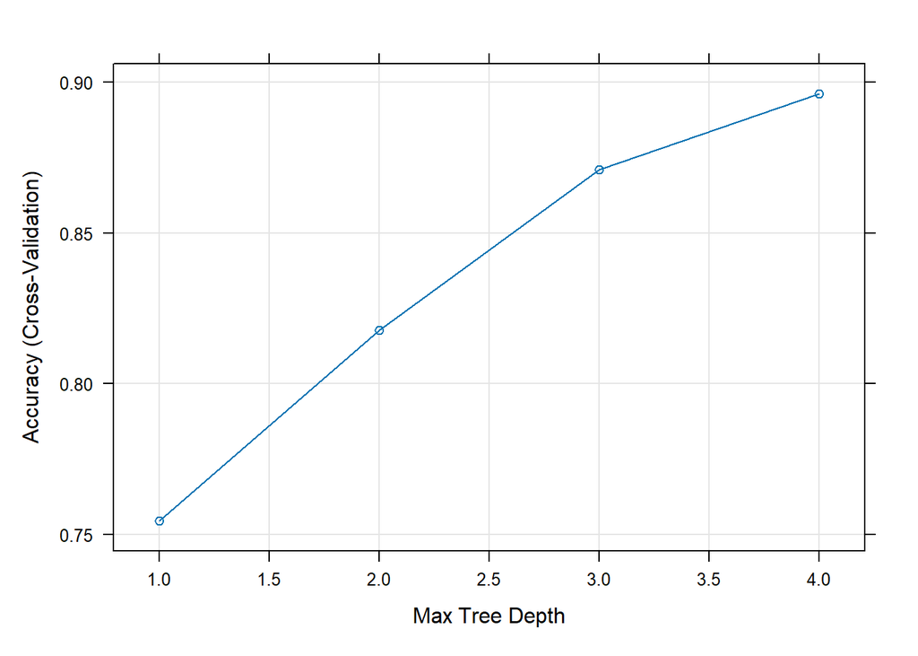

```r
# Plot the accuracy vs. hyperparameter values
plot(model)
```

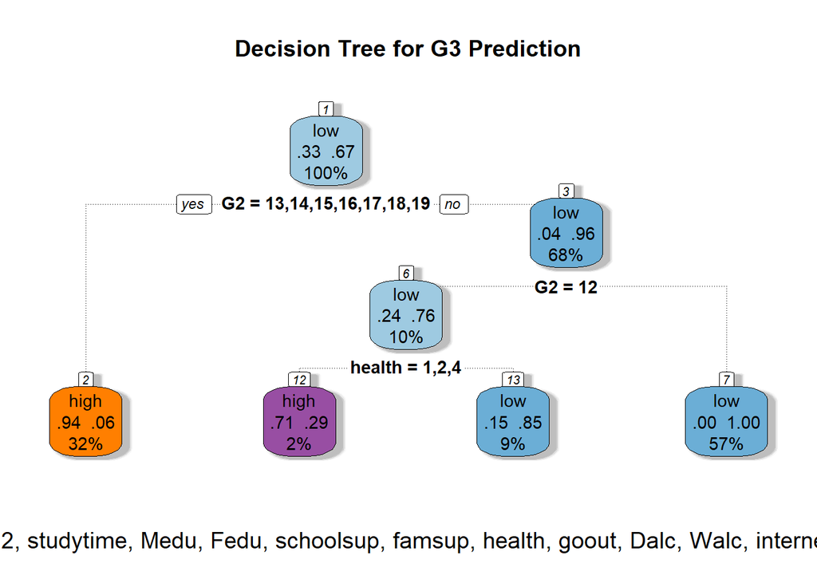

```r
# Build decision tree using the best 'maxdepth' found
best_maxdepth <- model$bestTune$maxdepth
final_tree <- rpart(G3bin ~ ., data = student_data[, c("G3bin", predictors)],
                     method = "class", control = rpart.control(maxdepth = best_maxdepth))

# Pretty print the tree using fancyRPartPlot
fancyRpartPlot(final_tree, main = "Decision Tree for G3 Prediction",
               sub = "Using G1, G2, studytime, Medu, Fedu, schoolsup, famsup, health, goout, Dalc, Walc, internet, romantic",
               caption = "Customized Decision Tree Plot", palettes = "Set1", type = 2)
```

f)

```r
# Load necessary libraries
library(caret)
library(rpart)
library(rpart.plot)
library(rattle)
# Assuming 'student_data' contains the dataset

# Define the predictors as specified
predictors <- c("G1", "G2", "studytime", "Medu", "Fedu", "schoolsup", "famsup", "health", "goout", "Dalc", "Walc", "internet", "romantic")

# Define the training control
train_control <- trainControl(method = "LOOCV", number = 5)

# Define the hyperparameter grid for 'maxdepth'
grid <- expand.grid(maxdepth = c(model$bestTune$maxdepth))

# Creating a new column where G3 scores are converted into qualitative values (binary)
student_data$G3 <- as.numeric(student_data$G3)
student_data$G3bin <- as.factor(ifelse(student_data$G3 > 10, "High", "Low"))
student_data$G3 <- as.factor(student_data$G3)


# Display the modified dataset with G3bin as a factor column
head(student_data)
```

```
##   school sex age address famsize Pstatus Medu Fedu     Mjob     Fjob     reason
## 1     GP   F  18       U     GT3       A    4    4  at_home  teacher     course
## 2     GP   F  17       U     GT3       T    1    1  at_home    other     course
## 3     GP   F  15       U     LE3       T    1    1  at_home    other      other
## 4     GP   F  15       U     GT3       T    4    2   health services       home
## 5     GP   F  16       U     GT3       T    3    3    other    other       home
## 6     GP   M  16       U     LE3       T    4    3 services    other reputation
##   guardian traveltime studytime failures schoolsup famsup paid activities
## 1   mother          2         2        0       yes     no   no         no
## 2   father          1         2        0        no    yes   no         no
## 3   mother          1         2        3       yes     no  yes         no
## 4   mother          1         3        0        no    yes  yes        yes
## 5   father          1         2        0        no    yes  yes         no
## 6   mother          1         2        0        no    yes  yes        yes
##   nursery higher internet romantic famrel freetime goout Dalc Walc health
## 1     yes    yes       no       no      4        3     4    1    1      3
## 2      no    yes      yes       no      5        3     3    1    1      3
## 3     yes    yes      yes       no      4        3     2    2    3      3
## 4     yes    yes      yes      yes      3        2     2    1    1      5
## 5     yes    yes       no       no      4        3     2    1    2      5
## 6     yes    yes      yes       no      5        4     2    1    2      5
##   absences G1 G2 G3 G3bin
## 1        6  5  6  4   Low
## 2        4  5  5  4   Low
## 3       10  7  8  8   Low
## 4        2 15 14 13  High
## 5        4  6 10  8   Low
## 6       10 15 15 13  High
```

```r
# Train the model using train() function and perform grid search
model <- train(G3bin ~ ., data = student_data[, c("G3bin", predictors)],
               method = "rpart2", trControl = train_control, tuneGrid = grid)

# Print table with accuracies for different hyperparameter values
print(model$results)
```

```
##   maxdepth  Accuracy    Kappa
## 1        4 0.9037975 0.772493
```

```r
train_predictions <- predict(model, data = student_data)
train_accuracy <- confusionMatrix(train_predictions, student_data$G3bin)$overall['Accuracy']
train_error_rate <- 1 - train_accuracy
print(paste("Accuracy:", train_accuracy))
```

```
## [1] "Accuracy: 0.90379746835443"
```

```r
print(paste("Error Rate:", train_error_rate))
```

```
## [1] "Error Rate: 0.0962025316455696"
```

## g) and h)

```r
# Install and load necessary libraries and packages


library(caret)
library(C50)  # Load the C50 package
# Define the predictors as specified
predictors <- c("G1", "G2", "studytime", "Medu", "Fedu", "schoolsup", "famsup", "health", "goout", "Dalc", "Walc", "internet", "romantic")

# Define the training control for 5-fold cross-validation
train_control <- trainControl(method = "CV", number = 5)

# Define the hyperparameter grid for 'trials' and 'minCases'
grid <- expand.grid(.model = "tree", .trials = c(1:100), .winnow = FALSE)
C5.0Control(
subset = TRUE,
bands = 0,
winnow = FALSE,
noGlobalPruning = FALSE,
CF = 0.25,
minCases = 2,
fuzzyThreshold = FALSE,
sample = 0,
seed = sample.int(4096, size = 1) - 1L,
earlyStopping = TRUE,
label = "outcome"
)
```

```
## $subset
## [1] TRUE
##
## $bands
## [1] 0
##
## $winnow
## [1] FALSE
##
## $noGlobalPruning
## [1] FALSE
##
## $CF
## [1] 0.25
##
## $minCases
## [1] 2
##
## $fuzzyThreshold
## [1] FALSE
##
## $sample
## [1] 0
##
## $earlyStopping
## [1] TRUE
##
## $label
## [1] "outcome"
##
## $seed
## [1] 1495
```

```r
# Creating a new column where G3 scores are converted into qualitative values (binary)
student_data$G3 <- as.numeric(student_data$G3)
student_data$G3bin <- as.factor(ifelse(student_data$G3 > 10, "high", "low"))
student_data$G3 <- as.factor(student_data$G3)




# Display the modified dataset with G3bin as a factor column
head(student_data)
```

```
##   school sex age address famsize Pstatus Medu Fedu     Mjob     Fjob     reason
## 1     GP   F  18       U     GT3       A    4    4  at_home  teacher     course
## 2     GP   F  17       U     GT3       T    1    1  at_home    other     course
## 3     GP   F  15       U     LE3       T    1    1  at_home    other      other
## 4     GP   F  15       U     GT3       T    4    2   health services       home
## 5     GP   F  16       U     GT3       T    3    3    other    other       home
## 6     GP   M  16       U     LE3       T    4    3 services    other reputation
##   guardian traveltime studytime failures schoolsup famsup paid activities
## 1   mother          2         2        0       yes     no   no         no
## 2   father          1         2        0        no    yes   no         no
## 3   mother          1         2        3       yes     no  yes         no
## 4   mother          1         3        0        no    yes  yes        yes
## 5   father          1         2        0        no    yes  yes         no
## 6   mother          1         2        0        no    yes  yes        yes
##   nursery higher internet romantic famrel freetime goout Dalc Walc health
## 1     yes    yes       no       no      4        3     4    1    1      3
## 2      no    yes      yes       no      5        3     3    1    1      3
## 3     yes    yes      yes       no      4        3     2    2    3      3
## 4     yes    yes      yes      yes      3        2     2    1    1      5
## 5     yes    yes       no       no      4        3     2    1    2      5
## 6     yes    yes      yes       no      5        4     2    1    2      5
##   absences G1 G2 G3 G3bin
## 1        6  5  6  4   low
## 2        4  5  5  4   low
## 3       10  7  8  8   low
## 4        2 15 14 13  high
## 5        4  6 10  8   low
## 6       10 15 15 13  high
```

```r
set.seed(826)
# Train the model using train() function with C5.0 algorithm and grid search
model1 <- train(G3bin ~ ., data = student_data[, c("G3bin", predictors)],
               method = "C5.0", trControl = train_control, tuneGrid = grid)


# Print table with accuracies for different hyperparameter values
print(model$results)
```

```
##   maxdepth  Accuracy    Kappa
## 1        4 0.9037975 0.772493
```

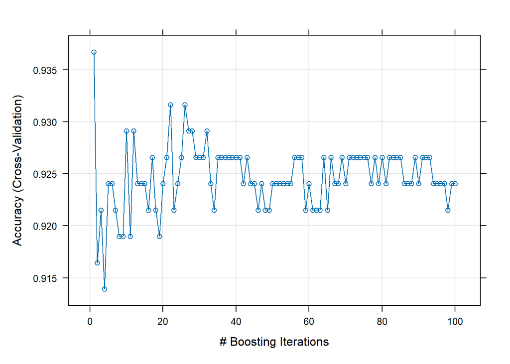

```r
final_tree <- rpart(G3bin ~ ., data = student_data[, c("G3bin", predictors)],
                     method = "class", control = rpart.control(maxdepth = 3))

# Plot the accuracy vs. hyperparameter values
plot(model1)
```

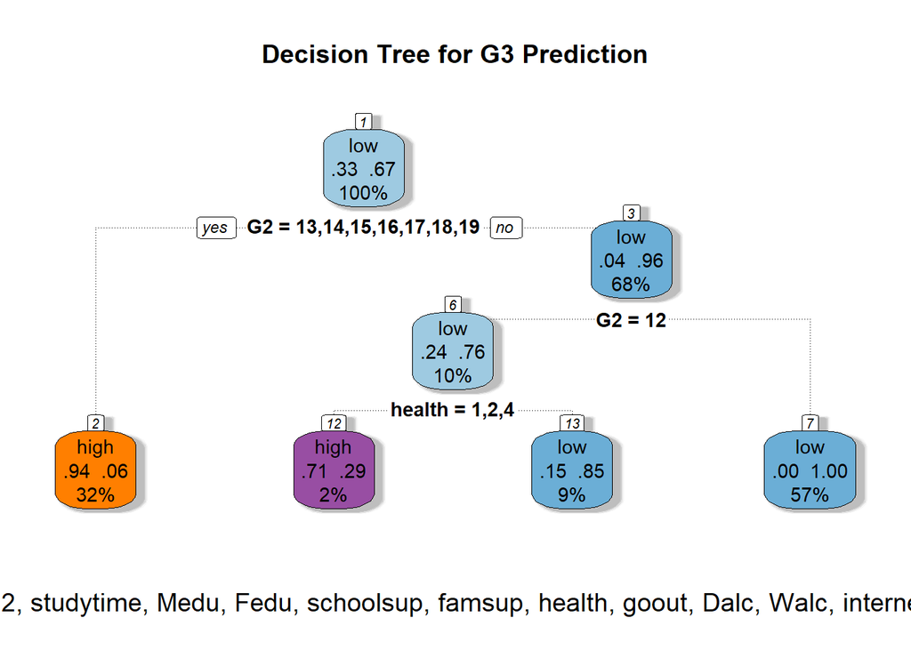

```r
# Pretty print the tree using fancyRpartPlot
fancyRpartPlot(final_tree, main = "Decision Tree for G3 Prediction",
               sub = "Using G1, G2, studytime, Medu, Fedu, schoolsup, famsup, health, goout, Dalc, Walc, internet, romantic",
               caption = "Customized Decision Tree Plot", palettes = "Set1", type = 2)
```

```r
train_predictions <- predict(model1, data = student_data)
train_accuracy <- confusionMatrix(train_predictions, student_data$G3bin)$overall['Accuracy']
train_error_rate <- 1 - train_accuracy
print(paste("Accuracy:", train_accuracy))
```

```
## [1] "Accuracy: 0.946835443037975"
```

```r
print(paste("Error Rate:", train_error_rate))
```

```
## [1] "Error Rate: 0.0531645569620253"
```

Although both the decision trees trained have accuracy above 90 percent, the decision tree made with C50 has a higher accuracy compared to the one trained with rpart2 in caret.

** i) ** From the trees I trained, I gained the insight that a student’s G2 scores and their health are two of the most important determinants of their G3 scores. In many schools and in a number of courses, there are three exams, the first being block 1, the second being block 2 and the third being block 3. The syllabus for the block 2 exam includes the syllabus for block 1 and the block 3 includes the syllabus for block 3. G1, G2 and G3 in the dataset can be considered equivalent to grades of a student in block 1 exam, block 2 exam and block 3 exam respectively. In our own course, we have a similar setup with a mid-term and a final exam, and the syllabus of the mid-term is included in that of the final exam. So, a student who does not perform well in block 2 exam or mid-term is more likely to perform worse than others in block 3 exam or final exam.  
Why G1 scores do not have so much impact on G3 scores might probably be because the syllabus covered in block 1 might command too low a proportion in the complete syllabus.  
According to my own observation, student health directly affect grades and mid-term grades also have a deep effect, not only on the score of the final exam, but also on the overall grade. Therefore, the decision trees constructed above align with my knowledge of student performance in the classroom.

ACTIVITY 2

Question 2 a)

```r
# Number of iterations
num_iterations <- 1000000

# Gradient descent optimization
grad_regr <- function(He, defaulte, pe, lambda, xe, max_iter) {
  p <- pe
  H <- He
  default <- defaulte
  x <- xe
  max_iter <- 1000000
  num_iter <- 0



  while (num_iter < max_iter)

    {
    #Compute the gradient
    gradient <- t(H) %*% (p-default)
    #Inside the loop, the gradient of the objective function is computed.
    #This computes the gradient of the Ridge regression objective function.


    #Take a step
    prev <- x
    x <- x - lambda * gradient
    #The coefficients x are updated using the gradient descent update rule.
    #lambda is the step size for the gradient descent, and prev is used to keep track of the previous          coefficients.




    # Increase the number of iterations
    num_iter <- num_iter + 1




  }

  return(x)
}
n <- 3
balance <- c(2500, 535, 3000)
default <- c(0, 1, 1)
H <- cbind(c(1, 1, 1), c(2500, 535, 3000))
# Given data
print(default)
```

```
## [1] 0 1 1
```

```r
# Learning rate (lambda)
lambda <- 0.00001
# Initial coefficients (a and b)
a <- 1
b <- 1
x <- c(1,1)
p <- 1 / (1 + exp(-(a + b * balance)))
print (H)
```

```
##      [,1] [,2]
## [1,]    1 2500
## [2,]    1  535
## [3,]    1 3000
```

```r
print (p)
```

```
## [1] 1 1 1
```

```r
max_iter <- num_iterations
result <- grad_regr(H, default, p, lambda, x, max_iter)
print(result)
```

```
##        [,1]
## [1,]     -9
## [2,] -24999
```

```r
#Final optimized coefficients
cat("Optimized coefficients after", num_iterations, "iterations:\n")
```

```
## Optimized coefficients after 1e+06 iterations:
```

```r
cat("Beta0:", result[1], "\n")
```

```
## Beta0: -9
```

```r
cat("Beta1:", result[2], "\n")
```

```
## Beta1: -24999
```

```r
df.name <- data.frame(balance = c(2500, 535, 3000),
 default = c(0,1,1))
model <- glm(default ~ ., data = df.name, family = "binomial")
summary(model)
```

```
##
## Call:
## glm(formula = default ~ ., family = "binomial", data = df.name)
##
## Coefficients:
##               Estimate Std. Error z value Pr(>|z|)
## (Intercept)  2.3719254  3.6760762   0.645    0.519
## balance     -0.0007714  0.0014624  -0.527    0.598
##
## (Dispersion parameter for binomial family taken to be 1)
##
##     Null deviance: 3.8191  on 2  degrees of freedom
## Residual deviance: 3.4716  on 1  degrees of freedom
## AIC: 7.4716
##
## Number of Fisher Scoring iterations: 4
```

| b) |
| --- |

```r
#Reading the dataset and assigning column names
library (readr)
setwd("C:/Users/Raj/Downloads/Machine Learning and Data Mining/Lab Assignments/Dataset for Homework 1/Adult")
adult <- read.table("adult.data", header = FALSE, sep = "\t", na = c('?'))
custom_column_names <- c('age', 'workclass', 'fnlwgt', 'education','education_num','marital_status','occupation','relationship', 'race', 'sex', 'capital_gain', 'capital_loss','hours_per_week', 'native_country', 'sal_range')
adult <- read_csv('adult.data', col_names = custom_column_names)
#Printing the dataset to verify the change
#adult
head(adult, 5)
```

```
## # A tibble: 5 × 15
##     age workclass       fnlwgt education education_num marital_status occupation
##   <dbl> <chr>            <dbl> <chr>             <dbl> <chr>          <chr>
## 1    39 State-gov        77516 Bachelors            13 Never-married  Adm-cleri…
## 2    50 Self-emp-not-i…  83311 Bachelors            13 Married-civ-s… Exec-mana…
## 3    38 Private         215646 HS-grad               9 Divorced       Handlers-…
## 4    53 Private         234721 11th                  7 Married-civ-s… Handlers-…
## 5    28 Private         338409 Bachelors            13 Married-civ-s… Prof-spec…
## # ℹ 8 more variables: relationship <chr>, race <chr>, sex <chr>,
## #   capital_gain <dbl>, capital_loss <dbl>, hours_per_week <dbl>,
## #   native_country <chr>, sal_range <chr>
```

```r
# Number of iterations
num_iterations <- 1000000

# Gradient descent optimization
grad_regr <- function(He, defaulte, pe, lambda, xe, max_iter) {
  p <- pe
  H <- He
  default <- defaulte
  x <- xe
  max_iter <- 1000000
  num_iter <- 0



  while (num_iter < max_iter)

    {
    #Compute the gradient
    gradient <- t(H) %*% (p-default)
    #Inside the loop, the gradient of the objective function is computed.
    #This computes the gradient of the Ridge regression objective function.


    #Take a step
    prev <- x
    x <- x - lambda * gradient
    #The coefficients x are updated using the gradient descent update rule.
    #lambda is the step size for the gradient descent, and prev is used to keep track of the previous          coefficients.




    # Increase the number of iterations
    num_iter <- num_iter + 1




  }

  return(x)
}
adult_small <- head(adult, 1000)

adult_small$income <- ifelse(adult_small$sal_range == '>50K', 1, 0)

H <- matrix(c(rbind(rep(1, 1000), adult_small$fnlwgt)), ncol=2, byrow=TRUE)
z <- matrix(adult_small$income, ncol=1)
p <- 1 / (1 + exp(-(a + b * adult_small$fnlwgt)))
x0 <- matrix(c(1, 1), ncol=1)


result <- grad_regr(H, z, p, 1e-6, x0, 10000000)
result
```

```
##            [,1]
## [1,]       -767
## [2,] -148107215
```

```r
#Reading the dataset and assigning column names
library (readr)
setwd("C:/Users/Raj/Downloads/Machine Learning and Data Mining/Lab Assignments/Dataset for Homework 1/Adult")
adult <- read.table("adult.data", header = FALSE, sep = "\t", na = c('?'))
custom_column_names <- c('age', 'workclass', 'fnlwgt', 'education','education_num','marital_status','occupation','relationship', 'race', 'sex', 'capital_gain', 'capital_loss','hours_per_week', 'native_country', 'sal_range')
adult <- read_csv('adult.data', col_names = custom_column_names)
#Printing the dataset to verify the change
#adult
head(adult, 5)
```

```
## # A tibble: 5 × 15
##     age workclass       fnlwgt education education_num marital_status occupation
##   <dbl> <chr>            <dbl> <chr>             <dbl> <chr>          <chr>
## 1    39 State-gov        77516 Bachelors            13 Never-married  Adm-cleri…
## 2    50 Self-emp-not-i…  83311 Bachelors            13 Married-civ-s… Exec-mana…
## 3    38 Private         215646 HS-grad               9 Divorced       Handlers-…
## 4    53 Private         234721 11th                  7 Married-civ-s… Handlers-…
## 5    28 Private         338409 Bachelors            13 Married-civ-s… Prof-spec…
## # ℹ 8 more variables: relationship <chr>, race <chr>, sex <chr>,
## #   capital_gain <dbl>, capital_loss <dbl>, hours_per_week <dbl>,
## #   native_country <chr>, sal_range <chr>
```

```r
model <- glm(as.factor(sal_range) ~., data = adult, family=binomial(logit))
summary(model)
```

```
##
## Call:
## glm(formula = as.factor(sal_range) ~ ., family = binomial(logit),
##     data = adult)
##
## Coefficients: (2 not defined because of singularities)
##                                            Estimate Std. Error z value Pr(>|z|)
## (Intercept)                              -9.074e+00  4.405e-01 -20.601  < 2e-16
## age                                       2.552e-02  1.651e-03  15.460  < 2e-16
## workclassFederal-gov                      1.097e+00  1.538e-01   7.131 9.99e-13
## workclassLocal-gov                        4.118e-01  1.403e-01   2.934  0.00334
## workclassNever-worked                    -1.045e+01  2.722e+02  -0.038  0.96936
## workclassPrivate                          5.944e-01  1.252e-01   4.746 2.08e-06
## workclassSelf-emp-inc                     7.694e-01  1.497e-01   5.140 2.74e-07
## workclassSelf-emp-not-inc                 1.037e-01  1.371e-01   0.756  0.44954
## workclassState-gov                        2.835e-01  1.518e-01   1.868  0.06173
## workclassWithout-pay                     -1.221e+01  1.985e+02  -0.062  0.95095
## fnlwgt                                    7.072e-07  1.720e-07   4.111 3.93e-05
## education11th                             8.500e-02  2.107e-01   0.403  0.68670
## education12th                             4.891e-01  2.644e-01   1.850  0.06435
## education1st-4th                         -5.322e-01  4.895e-01  -1.087  0.27696
## education5th-6th                         -2.386e-01  3.248e-01  -0.735  0.46255
## education7th-8th                         -4.755e-01  2.320e-01  -2.050  0.04039
## education9th                             -1.939e-01  2.612e-01  -0.743  0.45771
## educationAssoc-acdm                       1.336e+00  1.763e-01   7.574 3.63e-14
## educationAssoc-voc                        1.352e+00  1.694e-01   7.981 1.45e-15
## educationBachelors                        1.936e+00  1.575e-01  12.296  < 2e-16
## educationDoctorate                        2.989e+00  2.142e-01  13.954  < 2e-16
## educationHS-grad                          8.134e-01  1.534e-01   5.302 1.15e-07
## educationMasters                          2.289e+00  1.679e-01  13.631  < 2e-16
## educationPreschool                       -2.109e+01  3.665e+02  -0.058  0.95410
## educationProf-school                      2.793e+00  2.002e-01  13.955  < 2e-16
## educationSome-college                     1.159e+00  1.556e-01   7.447 9.52e-14
## education_num                                    NA         NA      NA       NA
## marital_statusMarried-AF-spouse           2.686e+00  5.538e-01   4.849 1.24e-06
## marital_statusMarried-civ-spouse          2.206e+00  2.654e-01   8.312  < 2e-16
## marital_statusMarried-spouse-absent      -1.097e-02  2.298e-01  -0.048  0.96192
## marital_statusNever-married              -4.825e-01  8.751e-02  -5.513 3.52e-08
## marital_statusSeparated                  -1.334e-01  1.641e-01  -0.813  0.41647
## marital_statusWidowed                     1.284e-01  1.538e-01   0.835  0.40350
```

[output cut: 165 more lines]

```
## native_countryThailand
## native_countryTrinadad&Tobago
## native_countryUnited-States              **
## native_countryVietnam
## native_countryYugoslavia
## ---
## Signif. codes:  0 '***' 0.001 '**' 0.01 '*' 0.05 '.' 0.1 ' ' 1
##
## (Dispersion parameter for binomial family taken to be 1)
##
##     Null deviance: 35948  on 32560  degrees of freedom
## Residual deviance: 20565  on 32462  degrees of freedom
## AIC: 20763
##
## Number of Fisher Scoring iterations: 13
```

4. The differences between the execution times of my implementation and R’s implementation arise becaueof the number of iterations (10^6).  
   The inbuilt glm function in R is implemented using optimized and specialized algorithms, which involve optimized matrix operations, convergence strategies, or specific optimizations tailored for logistic regression.  
   Gradient descent requires many more iterations to converge to a solution, especially because the learning rate has ti be chosen manually and therefore is not always optimal. Convergence rates differ based on the dataset, initialization, learning rate, and convergence criteria. The glm function utilizes more sophisticated algorithms that converge faster because it uses more efficient convergence criteria.  
   The inbuilt glm function internally uses optimized linear algebra libraries and leverage vectorized operations, leading to faster computations compared to non-vectorized custom implementations.

References:  
1. Khanafer, Ali H. “Logistic Regression Using Gradient Descent: Intuition and Implementation.” Geek Culture, 17 May 2021, medium.com/geekculture/logistic-regression-using-gradient-descent-intuition-and-implementation-36a8498afdcb. Accessed 30 Nov. 2023.  
2. “Logistic Regression in R Tutorial.” Www.datacamp.com, www.datacamp.com/tutorial/logistic-regression-R.  
3. Zou, Xiaonan, et al. “Logistic Regression Model Optimization and Case Analysis.” IEEE Xplore, 1 Oct. 2019, ieeexplore.ieee.org/document/8962457/.  
4. Prasad, Ashwin. “Logistic Regression with Gradient Descent Explained | Machine Learning.” Analytics Vidhya, 15 June 2021, medium.com/analytics-vidhya/logistic-regression-with-gradient-descent-explained-machine-learning-a9a12b38d710. Accessed 30 Nov. 2023.

Question 4 (implemented in Python)

| a), b), c), d) |
| --- |

import pandas as pd from sklearn.model_selection import train_test_split from sklearn.preprocessing import LabelEncoder from sklearn.preprocessing import StandardScaler from tensorflow.keras.models import Sequential from tensorflow.keras.layers import Dense, Dropout import matplotlib.pyplot as plt